# Risk Factor Analysis

## Outcome Variable

**Outcome Variable:** stunted

## Predictor Variables

**Intervention Variable:** enwast

**Adjustment Set:**

- arm
- sex
- W_mage
- meducyrs
- feducyrs
- W_mhtcm
- vagbrth
- single
- brthmon
- W_parity
- delta_W_mage
- delta_meducyrs
- delta_feducyrs
- delta_W_mhtcm
- delta_vagbrth
- delta_single
- delta_brthmon
- delta_W_parity

## Stratifying Variables

The analysis was stratified on these variable(s):

- agecat
- studyid
- country

## Data Summary

| agecat | studyid | country | enwast | stunted | n_cell | n |
| --- | --- | --- | --- | --- | --- | --- |
| Birth | ki0047075b-MAL-ED | BANGLADESH | 0 | 0 | 174 | 241 |
| Birth | ki0047075b-MAL-ED | BANGLADESH | 0 | 1 | 27 | 241 |
| Birth | ki0047075b-MAL-ED | BANGLADESH | 1 | 0 | 36 | 241 |
| Birth | ki0047075b-MAL-ED | BANGLADESH | 1 | 1 | 4 | 241 |
| 6 months | ki0047075b-MAL-ED | BANGLADESH | 0 | 0 | 152 | 221 |
| 6 months | ki0047075b-MAL-ED | BANGLADESH | 0 | 1 | 30 | 221 |
| 6 months | ki0047075b-MAL-ED | BANGLADESH | 1 | 0 | 33 | 221 |
| 6 months | ki0047075b-MAL-ED | BANGLADESH | 1 | 1 | 6 | 221 |
| 24 months | ki0047075b-MAL-ED | BANGLADESH | 0 | 0 | 90 | 195 |
| 24 months | ki0047075b-MAL-ED | BANGLADESH | 0 | 1 | 70 | 195 |
| 24 months | ki0047075b-MAL-ED | BANGLADESH | 1 | 0 | 22 | 195 |
| 24 months | ki0047075b-MAL-ED | BANGLADESH | 1 | 1 | 13 | 195 |
| Birth | ki0047075b-MAL-ED | BRAZIL | 0 | 0 | 163 | 183 |
| Birth | ki0047075b-MAL-ED | BRAZIL | 0 | 1 | 14 | 183 |
| Birth | ki0047075b-MAL-ED | BRAZIL | 1 | 0 | 6 | 183 |
| Birth | ki0047075b-MAL-ED | BRAZIL | 1 | 1 | 0 | 183 |
| 6 months | ki0047075b-MAL-ED | BRAZIL | 0 | 0 | 156 | 166 |
| 6 months | ki0047075b-MAL-ED | BRAZIL | 0 | 1 | 4 | 166 |
| 6 months | ki0047075b-MAL-ED | BRAZIL | 1 | 0 | 6 | 166 |
| 6 months | ki0047075b-MAL-ED | BRAZIL | 1 | 1 | 0 | 166 |
| 24 months | ki0047075b-MAL-ED | BRAZIL | 0 | 0 | 122 | 133 |
| 24 months | ki0047075b-MAL-ED | BRAZIL | 0 | 1 | 6 | 133 |
| 24 months | ki0047075b-MAL-ED | BRAZIL | 1 | 0 | 5 | 133 |
| 24 months | ki0047075b-MAL-ED | BRAZIL | 1 | 1 | 0 | 133 |
| Birth | ki0047075b-MAL-ED | INDIA | 0 | 0 | 146 | 203 |
| Birth | ki0047075b-MAL-ED | INDIA | 0 | 1 | 24 | 203 |
| Birth | ki0047075b-MAL-ED | INDIA | 1 | 0 | 27 | 203 |
| Birth | ki0047075b-MAL-ED | INDIA | 1 | 1 | 6 | 203 |
| 6 months | ki0047075b-MAL-ED | INDIA | 0 | 0 | 129 | 189 |
| 6 months | ki0047075b-MAL-ED | INDIA | 0 | 1 | 30 | 189 |

[output cut: 280 more lines]

The following strata were considered:

- agecat: 24 months, studyid: ki0047075b-MAL-ED, country: BANGLADESH
- agecat: 24 months, studyid: ki0047075b-MAL-ED, country: BRAZIL
- agecat: 24 months, studyid: ki0047075b-MAL-ED, country: INDIA
- agecat: 24 months, studyid: ki0047075b-MAL-ED, country: NEPAL
- agecat: 24 months, studyid: ki0047075b-MAL-ED, country: PERU
- agecat: 24 months, studyid: ki0047075b-MAL-ED, country: SOUTH AFRICA
- agecat: 24 months, studyid: ki0047075b-MAL-ED, country: TANZANIA, UNITED REPUBLIC OF
- agecat: 24 months, studyid: ki1000108-CMC-V-BCS-2002, country: INDIA
- agecat: 24 months, studyid: ki1000108-IRC, country: INDIA
- agecat: 24 months, studyid: ki1017093-NIH-Birth, country: BANGLADESH
- agecat: 24 months, studyid: ki1017093c-NIH-Crypto, country: BANGLADESH
- agecat: 24 months, studyid: ki1101329-Keneba, country: GAMBIA
- agecat: 24 months, studyid: ki1113344-GMS-Nepal, country: NEPAL
- agecat: 24 months, studyid: ki1114097-CMIN, country: GUINEA-BISSAU
- agecat: 24 months, studyid: ki1114097-CMIN, country: PERU
- agecat: 24 months, studyid: ki1114097-CONTENT, country: PERU
- agecat: 24 months, studyid: ki1119695-PROBIT, country: BELARUS
- agecat: 24 months, studyid: ki1126311-ZVITAMBO, country: ZIMBABWE
- agecat: 24 months, studyid: ki1135781-COHORTS, country: GUATEMALA
- agecat: 24 months, studyid: ki1135781-COHORTS, country: INDIA
- agecat: 24 months, studyid: ki1135781-COHORTS, country: PHILIPPINES
- agecat: 24 months, studyid: ki1148112-LCNI-5, country: MALAWI
- agecat: 24 months, studyid: kiGH5241-JiVitA-3, country: BANGLADESH
- agecat: 24 months, studyid: kiGH5241-JiVitA-4, country: BANGLADESH
- agecat: 6 months, studyid: ki0047075b-MAL-ED, country: BANGLADESH
- agecat: 6 months, studyid: ki0047075b-MAL-ED, country: BRAZIL
- agecat: 6 months, studyid: ki0047075b-MAL-ED, country: INDIA
- agecat: 6 months, studyid: ki0047075b-MAL-ED, country: NEPAL
- agecat: 6 months, studyid: ki0047075b-MAL-ED, country: PERU
- agecat: 6 months, studyid: ki0047075b-MAL-ED, country: SOUTH AFRICA
- agecat: 6 months, studyid: ki0047075b-MAL-ED, country: TANZANIA, UNITED REPUBLIC OF
- agecat: 6 months, studyid: ki1000108-CMC-V-BCS-2002, country: INDIA
- agecat: 6 months, studyid: ki1000108-IRC, country: INDIA
- agecat: 6 months, studyid: ki1000109-EE, country: PAKISTAN
- agecat: 6 months, studyid: ki1000109-ResPak, country: PAKISTAN
- agecat: 6 months, studyid: ki1000304b-SAS-CompFeed, country: INDIA
- agecat: 6 months, studyid: ki1000304b-SAS-FoodSuppl, country: INDIA
- agecat: 6 months, studyid: ki1017093-NIH-Birth, country: BANGLADESH
- agecat: 6 months, studyid: ki1017093c-NIH-Crypto, country: BANGLADESH
- agecat: 6 months, studyid: ki1066203-TanzaniaChild2, country: TANZANIA, UNITED REPUBLIC OF
- agecat: 6 months, studyid: ki1101329-Keneba, country: GAMBIA
- agecat: 6 months, studyid: ki1112895-Guatemala BSC, country: GUATEMALA
- agecat: 6 months, studyid: ki1113344-GMS-Nepal, country: NEPAL
- agecat: 6 months, studyid: ki1114097-CMIN, country: BRAZIL
- agecat: 6 months, studyid: ki1114097-CMIN, country: GUINEA-BISSAU
- agecat: 6 months, studyid: ki1114097-CMIN, country: PERU
- agecat: 6 months, studyid: ki1114097-CONTENT, country: PERU
- agecat: 6 months, studyid: ki1119695-PROBIT, country: BELARUS
- agecat: 6 months, studyid: ki1126311-ZVITAMBO, country: ZIMBABWE
- agecat: 6 months, studyid: ki1135781-COHORTS, country: GUATEMALA
- agecat: 6 months, studyid: ki1135781-COHORTS, country: INDIA
- agecat: 6 months, studyid: ki1135781-COHORTS, country: PHILIPPINES
- agecat: 6 months, studyid: ki1148112-LCNI-5, country: MALAWI
- agecat: 6 months, studyid: kiGH5241-JiVitA-3, country: BANGLADESH
- agecat: 6 months, studyid: kiGH5241-JiVitA-4, country: BANGLADESH
- agecat: Birth, studyid: ki0047075b-MAL-ED, country: BANGLADESH
- agecat: Birth, studyid: ki0047075b-MAL-ED, country: BRAZIL
- agecat: Birth, studyid: ki0047075b-MAL-ED, country: INDIA
- agecat: Birth, studyid: ki0047075b-MAL-ED, country: NEPAL
- agecat: Birth, studyid: ki0047075b-MAL-ED, country: PERU
- agecat: Birth, studyid: ki0047075b-MAL-ED, country: SOUTH AFRICA
- agecat: Birth, studyid: ki0047075b-MAL-ED, country: TANZANIA, UNITED REPUBLIC OF
- agecat: Birth, studyid: ki1000108-CMC-V-BCS-2002, country: INDIA
- agecat: Birth, studyid: ki1000108-IRC, country: INDIA
- agecat: Birth, studyid: ki1000109-EE, country: PAKISTAN
- agecat: Birth, studyid: ki1000109-ResPak, country: PAKISTAN
- agecat: Birth, studyid: ki1000304b-SAS-CompFeed, country: INDIA
- agecat: Birth, studyid: ki1017093-NIH-Birth, country: BANGLADESH
- agecat: Birth, studyid: ki1017093c-NIH-Crypto, country: BANGLADESH
- agecat: Birth, studyid: ki1101329-Keneba, country: GAMBIA
- agecat: Birth, studyid: ki1114097-CMIN, country: BANGLADESH
- agecat: Birth, studyid: ki1114097-CMIN, country: BRAZIL
- agecat: Birth, studyid: ki1114097-CMIN, country: PERU
- agecat: Birth, studyid: ki1114097-CONTENT, country: PERU
- agecat: Birth, studyid: ki1119695-PROBIT, country: BELARUS
- agecat: Birth, studyid: ki1126311-ZVITAMBO, country: ZIMBABWE
- agecat: Birth, studyid: ki1135781-COHORTS, country: GUATEMALA
- agecat: Birth, studyid: ki1135781-COHORTS, country: INDIA
- agecat: Birth, studyid: ki1135781-COHORTS, country: PHILIPPINES
- agecat: Birth, studyid: kiGH5241-JiVitA-3, country: BANGLADESH
- agecat: Birth, studyid: kiGH5241-JiVitA-4, country: BANGLADESH

### Dropped Strata

Some strata were dropped due to rare outcomes:

- agecat: Birth, studyid: ki0047075b-MAL-ED, country: BANGLADESH
- agecat: Birth, studyid: ki0047075b-MAL-ED, country: BRAZIL
- agecat: 6 months, studyid: ki0047075b-MAL-ED, country: BRAZIL
- agecat: 24 months, studyid: ki0047075b-MAL-ED, country: BRAZIL
- agecat: Birth, studyid: ki0047075b-MAL-ED, country: NEPAL
- agecat: 6 months, studyid: ki0047075b-MAL-ED, country: NEPAL
- agecat: Birth, studyid: ki0047075b-MAL-ED, country: PERU
- agecat: 6 months, studyid: ki0047075b-MAL-ED, country: PERU
- agecat: 24 months, studyid: ki0047075b-MAL-ED, country: PERU
- agecat: Birth, studyid: ki0047075b-MAL-ED, country: SOUTH AFRICA
- agecat: 6 months, studyid: ki0047075b-MAL-ED, country: SOUTH AFRICA
- agecat: 24 months, studyid: ki0047075b-MAL-ED, country: SOUTH AFRICA
- agecat: Birth, studyid: ki0047075b-MAL-ED, country: TANZANIA, UNITED REPUBLIC OF
- agecat: 6 months, studyid: ki0047075b-MAL-ED, country: TANZANIA, UNITED REPUBLIC OF
- agecat: 24 months, studyid: ki0047075b-MAL-ED, country: TANZANIA, UNITED REPUBLIC OF
- agecat: Birth, studyid: ki1000108-CMC-V-BCS-2002, country: INDIA
- agecat: 6 months, studyid: ki1000108-CMC-V-BCS-2002, country: INDIA
- agecat: 24 months, studyid: ki1000108-CMC-V-BCS-2002, country: INDIA
- agecat: Birth, studyid: ki1000108-IRC, country: INDIA
- agecat: 6 months, studyid: ki1000109-EE, country: PAKISTAN
- agecat: Birth, studyid: ki1000109-EE, country: PAKISTAN
- agecat: Birth, studyid: ki1000109-ResPak, country: PAKISTAN
- agecat: Birth, studyid: ki1000304b-SAS-CompFeed, country: INDIA
- agecat: Birth, studyid: ki1017093-NIH-Birth, country: BANGLADESH
- agecat: Birth, studyid: ki1017093c-NIH-Crypto, country: BANGLADESH
- agecat: 6 months, studyid: ki1017093c-NIH-Crypto, country: BANGLADESH
- agecat: 24 months, studyid: ki1017093c-NIH-Crypto, country: BANGLADESH
- agecat: 6 months, studyid: ki1066203-TanzaniaChild2, country: TANZANIA, UNITED REPUBLIC OF
- agecat: Birth, studyid: ki1101329-Keneba, country: GAMBIA
- agecat: 6 months, studyid: ki1112895-Guatemala BSC, country: GUATEMALA
- agecat: 6 months, studyid: ki1113344-GMS-Nepal, country: NEPAL
- agecat: 24 months, studyid: ki1113344-GMS-Nepal, country: NEPAL
- agecat: Birth, studyid: ki1114097-CMIN, country: BANGLADESH
- agecat: Birth, studyid: ki1114097-CMIN, country: BRAZIL
- agecat: 6 months, studyid: ki1114097-CMIN, country: BRAZIL
- agecat: 24 months, studyid: ki1114097-CMIN, country: GUINEA-BISSAU
- agecat: 6 months, studyid: ki1114097-CMIN, country: GUINEA-BISSAU
- agecat: 6 months, studyid: ki1114097-CMIN, country: PERU
- agecat: 24 months, studyid: ki1114097-CMIN, country: PERU
- agecat: Birth, studyid: ki1114097-CONTENT, country: PERU
- agecat: Birth, studyid: ki1119695-PROBIT, country: BELARUS
- agecat: Birth, studyid: ki1135781-COHORTS, country: GUATEMALA
- agecat: 24 months, studyid: ki1148112-LCNI-5, country: MALAWI

## Methods Detail

We’re interested in the causal parameters $E[Y_a]$ for all values of $a \in \mathcal{A}$. These parameters represent the mean outcome if, possibly contrary to fact, we intervened to set all units to have $A=a$. Under the randomization and positivity assumptions, these are identified by the statistical parameters $\psi_a=E_W[E_{Y|A,W}(Y|A=a,W)]$. In addition, we’re interested in the mean of $Y$, $E[Y]$ under no intervention (the observed mean). We will estimate these parameters by using SuperLearner to fit the relevant likelihood factors – $E_{Y|A,W}(Y|A=a,W)$ and $p(A=a|W)$, and then updating our likelihood fit using a joint TMLE.

For unadjusted analyses ($W=\{\}$), initial likelihoods were estimated using Lrnr_glm to estimate the simple $E(Y|A)$ and Lrnr_mean to estimate $p(A)$. For adjusted analyses, a small library containing Lrnr_glmnet, Lrnr_xgboost, and Lrnr_mean was used.

Having estimated these parameters, we will then use the delta method to estimate relative risks and attributable risks relative to a prespecified baseline level of $A$.

```
##       stunted
## enwast  0  1
##      0 39  7
##      1  0  0
```

```
##       stunted
## enwast  0  1
##      0 48  7
##      1  0  0
##       stunted
## enwast  0
##      0 10
##      1  0
```

# Results Detail

## Results Plots

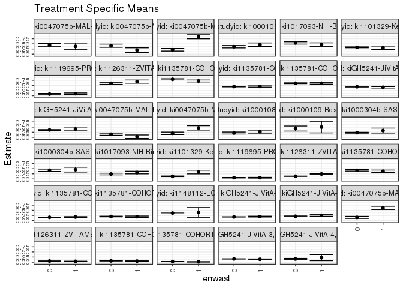

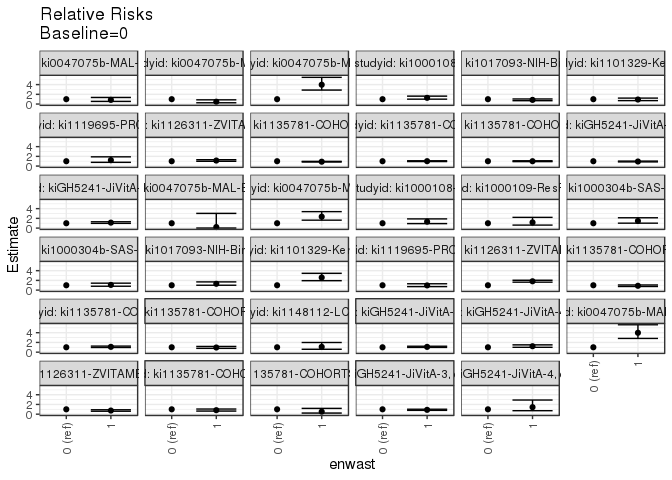

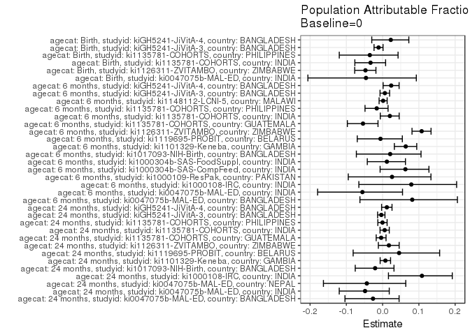

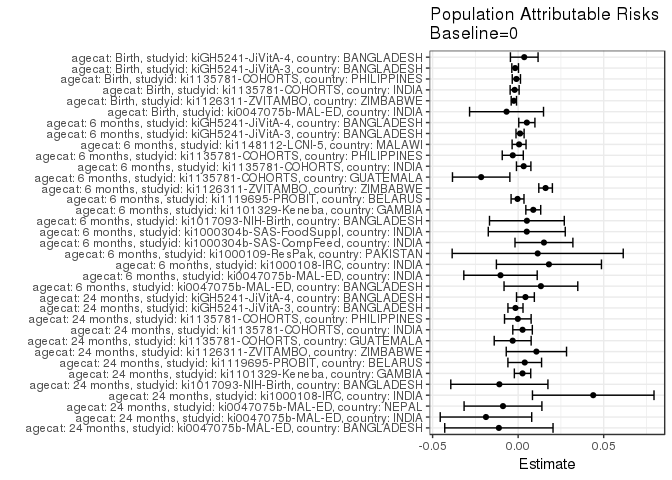

## Results Table

### Parameter: TSM

| agecat | studyid | country | intervention_level | baseline_level | estimate | ci_lower | ci_upper |
| --- | --- | --- | --- | --- | --- | --- | --- |
| Birth | ki0047075b-MAL-ED | INDIA | 0 | NA | 0.1545657 | 0.1036966 | 0.2054347 |
| Birth | ki0047075b-MAL-ED | INDIA | 1 | NA | 0.6157475 | 0.5381970 | 0.6932981 |
| Birth | ki1126311-ZVITAMBO | ZIMBABWE | 0 | NA | 0.0555150 | 0.0512372 | 0.0597928 |
| Birth | ki1126311-ZVITAMBO | ZIMBABWE | 1 | NA | 0.0412944 | 0.0336652 | 0.0489236 |
| Birth | ki1135781-COHORTS | INDIA | 0 | NA | 0.0638423 | 0.0571716 | 0.0705130 |
| Birth | ki1135781-COHORTS | INDIA | 1 | NA | 0.0523602 | 0.0402909 | 0.0644296 |
| Birth | ki1135781-COHORTS | PHILIPPINES | 0 | NA | 0.0305954 | 0.0237884 | 0.0374025 |
| Birth | ki1135781-COHORTS | PHILIPPINES | 1 | NA | 0.0158555 | 0.0031404 | 0.0285707 |
| Birth | kiGH5241-JiVitA-3 | BANGLADESH | 0 | NA | 0.1586225 | 0.1520027 | 0.1652422 |
| Birth | kiGH5241-JiVitA-3 | BANGLADESH | 1 | NA | 0.1412523 | 0.1236800 | 0.1588246 |
| Birth | kiGH5241-JiVitA-4 | BANGLADESH | 0 | NA | 0.1545595 | 0.1236384 | 0.1854806 |
| Birth | kiGH5241-JiVitA-4 | BANGLADESH | 1 | NA | 0.2222222 | 0.0728779 | 0.3715666 |
| 6 months | ki0047075b-MAL-ED | BANGLADESH | 0 | NA | 0.1495910 | 0.0967632 | 0.2024188 |
| 6 months | ki0047075b-MAL-ED | BANGLADESH | 1 | NA | 0.0316364 | -0.0517552 | 0.1150279 |
| 6 months | ki0047075b-MAL-ED | INDIA | 0 | NA | 0.1954958 | 0.1357569 | 0.2552347 |
| 6 months | ki0047075b-MAL-ED | INDIA | 1 | NA | 0.4592398 | 0.3524469 | 0.5660326 |
| 6 months | ki1000108-IRC | INDIA | 0 | NA | 0.2093976 | 0.1600671 | 0.2587280 |
| 6 months | ki1000108-IRC | INDIA | 1 | NA | 0.2767836 | 0.2026133 | 0.3509540 |
| 6 months | ki1000109-ResPak | PAKISTAN | 0 | NA | 0.4285714 | 0.3055488 | 0.5515941 |
| 6 months | ki1000109-ResPak | PAKISTAN | 1 | NA | 0.5000000 | 0.2151985 | 0.7848015 |
| 6 months | ki1000304b-SAS-CompFeed | INDIA | 0 | NA | 0.2247891 | 0.2012701 | 0.2483082 |
| 6 months | ki1000304b-SAS-CompFeed | INDIA | 1 | NA | 0.3292797 | 0.2075881 | 0.4509714 |
| 6 months | ki1000304b-SAS-FoodSuppl | INDIA | 0 | NA | 0.4227531 | 0.3675167 | 0.4779896 |
| 6 months | ki1000304b-SAS-FoodSuppl | INDIA | 1 | NA | 0.4519837 | 0.3338510 | 0.5701163 |
| 6 months | ki1017093-NIH-Birth | BANGLADESH | 0 | NA | 0.2399865 | 0.1978999 | 0.2820730 |
| 6 months | ki1017093-NIH-Birth | BANGLADESH | 1 | NA | 0.3127420 | 0.2489972 | 0.3764867 |
| 6 months | ki1101329-Keneba | GAMBIA | 0 | NA | 0.1298186 | 0.1151034 | 0.1445339 |
| 6 months | ki1101329-Keneba | GAMBIA | 1 | NA | 0.3363101 | 0.2468285 | 0.4257917 |
| 6 months | ki1119695-PROBIT | BELARUS | 0 | NA | 0.0610222 | 0.0473053 | 0.0747391 |
| 6 months | ki1119695-PROBIT | BELARUS | 1 | NA | 0.0592801 | 0.0406377 | 0.0779224 |
| 6 months | ki1126311-ZVITAMBO | ZIMBABWE | 0 | NA | 0.1328809 | 0.1246957 | 0.1410661 |
| 6 months | ki1126311-ZVITAMBO | ZIMBABWE | 1 | NA | 0.2416683 | 0.2199285 | 0.2634081 |
| 6 months | ki1135781-COHORTS | GUATEMALA | 0 | NA | 0.4210959 | 0.3828045 | 0.4593873 |
| 6 months | ki1135781-COHORTS | GUATEMALA | 1 | NA | 0.3757897 | 0.3190897 | 0.4324896 |
| 6 months | ki1135781-COHORTS | INDIA | 0 | NA | 0.1587031 | 0.1488786 | 0.1685277 |
| 6 months | ki1135781-COHORTS | INDIA | 1 | NA | 0.1728439 | 0.1522333 | 0.1934545 |
| 6 months | ki1135781-COHORTS | PHILIPPINES | 0 | NA | 0.1968033 | 0.1802214 | 0.2133852 |
| 6 months | ki1135781-COHORTS | PHILIPPINES | 1 | NA | 0.1876121 | 0.1524502 | 0.2227740 |
| 6 months | ki1148112-LCNI-5 | MALAWI | 0 | NA | 0.3662845 | 0.3331573 | 0.3994117 |
| 6 months | ki1148112-LCNI-5 | MALAWI | 1 | NA | 0.3973439 | 0.1599150 | 0.6347728 |
| 6 months | kiGH5241-JiVitA-3 | BANGLADESH | 0 | NA | 0.1781560 | 0.1703598 | 0.1859522 |
| 6 months | kiGH5241-JiVitA-3 | BANGLADESH | 1 | NA | 0.1928001 | 0.1714745 | 0.2141256 |
| 6 months | kiGH5241-JiVitA-4 | BANGLADESH | 0 | NA | 0.2095453 | 0.1948807 | 0.2242100 |
| 6 months | kiGH5241-JiVitA-4 | BANGLADESH | 1 | NA | 0.2561151 | 0.2083123 | 0.3039180 |
| 24 months | ki0047075b-MAL-ED | BANGLADESH | 0 | NA | 0.4369004 | 0.3608651 | 0.5129356 |
| 24 months | ki0047075b-MAL-ED | BANGLADESH | 1 | NA | 0.3745584 | 0.2144953 | 0.5346216 |
| 24 months | ki0047075b-MAL-ED | INDIA | 0 | NA | 0.4076982 | 0.3302758 | 0.4851207 |
| 24 months | ki0047075b-MAL-ED | INDIA | 1 | NA | 0.1954401 | 0.0839148 | 0.3069653 |
| 24 months | ki0047075b-MAL-ED | NEPAL | 0 | NA | 0.2125611 | 0.1477685 | 0.2773538 |
| 24 months | ki0047075b-MAL-ED | NEPAL | 1 | NA | 0.8442388 | 0.7475437 | 0.9409339 |
| 24 months | ki1000108-IRC | INDIA | 0 | NA | 0.3607501 | 0.3023663 | 0.4191339 |
| 24 months | ki1000108-IRC | INDIA | 1 | NA | 0.4605730 | 0.3779058 | 0.5432402 |
| 24 months | ki1017093-NIH-Birth | BANGLADESH | 0 | NA | 0.5430000 | 0.4870543 | 0.5989457 |
| 24 months | ki1017093-NIH-Birth | BANGLADESH | 1 | NA | 0.4634059 | 0.3791431 | 0.5476687 |
| 24 months | ki1101329-Keneba | GAMBIA | 0 | NA | 0.3309587 | 0.3081812 | 0.3537363 |
| 24 months | ki1101329-Keneba | GAMBIA | 1 | NA | 0.3074633 | 0.2239210 | 0.3910057 |
| 24 months | ki1119695-PROBIT | BELARUS | 0 | NA | 0.0809853 | 0.0496979 | 0.1122727 |
| 24 months | ki1119695-PROBIT | BELARUS | 1 | NA | 0.0979916 | 0.0594991 | 0.1364841 |
| 24 months | ki1126311-ZVITAMBO | ZIMBABWE | 0 | NA | 0.6037316 | 0.5526847 | 0.6547785 |
| 24 months | ki1126311-ZVITAMBO | ZIMBABWE | 1 | NA | 0.6863229 | 0.6076294 | 0.7650164 |
| 24 months | ki1135781-COHORTS | GUATEMALA | 0 | NA | 0.7987982 | 0.7710221 | 0.8265742 |
| 24 months | ki1135781-COHORTS | GUATEMALA | 1 | NA | 0.7175161 | 0.6693760 | 0.7656562 |
| 24 months | ki1135781-COHORTS | INDIA | 0 | NA | 0.4461128 | 0.4311665 | 0.4610590 |
| 24 months | ki1135781-COHORTS | INDIA | 1 | NA | 0.4496961 | 0.4187496 | 0.4806426 |
| 24 months | ki1135781-COHORTS | PHILIPPINES | 0 | NA | 0.6082890 | 0.5870697 | 0.6295083 |
| 24 months | ki1135781-COHORTS | PHILIPPINES | 1 | NA | 0.6074830 | 0.5616166 | 0.6533494 |
| 24 months | kiGH5241-JiVitA-3 | BANGLADESH | 0 | NA | 0.4371090 | 0.4224292 | 0.4517887 |
| 24 months | kiGH5241-JiVitA-3 | BANGLADESH | 1 | NA | 0.4097668 | 0.3743078 | 0.4452258 |
| 24 months | kiGH5241-JiVitA-4 | BANGLADESH | 0 | NA | 0.3597129 | 0.3404294 | 0.3789963 |
| 24 months | kiGH5241-JiVitA-4 | BANGLADESH | 1 | NA | 0.4040391 | 0.3490424 | 0.4590358 |

### Parameter: E(Y)

| agecat | studyid | country | intervention_level | baseline_level | estimate | ci_lower | ci_upper |
| --- | --- | --- | --- | --- | --- | --- | --- |
| Birth | ki0047075b-MAL-ED | INDIA | NA | NA | 0.1477833 | 0.0988437 | 0.1967228 |
| Birth | ki1126311-ZVITAMBO | ZIMBABWE | NA | NA | 0.0530095 | 0.0491714 | 0.0568475 |
| Birth | ki1135781-COHORTS | INDIA | NA | NA | 0.0617878 | 0.0558091 | 0.0677665 |
| Birth | ki1135781-COHORTS | PHILIPPINES | NA | NA | 0.0295533 | 0.0233992 | 0.0357074 |
| Birth | kiGH5241-JiVitA-3 | BANGLADESH | NA | NA | 0.1568752 | 0.1505743 | 0.1631761 |
| Birth | kiGH5241-JiVitA-4 | BANGLADESH | NA | NA | 0.1581259 | 0.1278797 | 0.1883722 |
| 6 months | ki0047075b-MAL-ED | BANGLADESH | NA | NA | 0.1628959 | 0.1141002 | 0.2116916 |
| 6 months | ki0047075b-MAL-ED | INDIA | NA | NA | 0.1851852 | 0.1296585 | 0.2407119 |
| 6 months | ki1000108-IRC | INDIA | NA | NA | 0.2273902 | 0.1855763 | 0.2692041 |
| 6 months | ki1000109-ResPak | PAKISTAN | NA | NA | 0.4400000 | 0.3269026 | 0.5530974 |
| 6 months | ki1000304b-SAS-CompFeed | INDIA | NA | NA | 0.2398677 | 0.2129210 | 0.2668143 |
| 6 months | ki1000304b-SAS-FoodSuppl | INDIA | NA | NA | 0.4277929 | 0.3771054 | 0.4784804 |
| 6 months | ki1017093-NIH-Birth | BANGLADESH | NA | NA | 0.2450980 | 0.2077296 | 0.2824664 |
| 6 months | ki1101329-Keneba | GAMBIA | NA | NA | 0.1386615 | 0.1237954 | 0.1535277 |
| 6 months | ki1119695-PROBIT | BELARUS | NA | NA | 0.0606682 | 0.0476558 | 0.0736805 |
| 6 months | ki1126311-ZVITAMBO | ZIMBABWE | NA | NA | 0.1489224 | 0.1409953 | 0.1568496 |
| 6 months | ki1135781-COHORTS | GUATEMALA | NA | NA | 0.3994845 | 0.3650012 | 0.4339679 |
| 6 months | ki1135781-COHORTS | INDIA | NA | NA | 0.1619376 | 0.1528966 | 0.1709786 |
| 6 months | ki1135781-COHORTS | PHILIPPINES | NA | NA | 0.1936606 | 0.1784301 | 0.2088911 |
| 6 months | ki1148112-LCNI-5 | MALAWI | NA | NA | 0.3668281 | 0.3339419 | 0.3997143 |
| 6 months | kiGH5241-JiVitA-3 | BANGLADESH | NA | NA | 0.1792723 | 0.1716642 | 0.1868804 |
| 6 months | kiGH5241-JiVitA-4 | BANGLADESH | NA | NA | 0.2146283 | 0.2007318 | 0.2285248 |
| 24 months | ki0047075b-MAL-ED | BANGLADESH | NA | NA | 0.4256410 | 0.3560648 | 0.4952172 |
| 24 months | ki0047075b-MAL-ED | INDIA | NA | NA | 0.3888889 | 0.3174731 | 0.4603047 |
| 24 months | ki0047075b-MAL-ED | NEPAL | NA | NA | 0.2037037 | 0.1414920 | 0.2659154 |
| 24 months | ki1000108-IRC | INDIA | NA | NA | 0.4046392 | 0.3557383 | 0.4535401 |
| 24 months | ki1017093-NIH-Birth | BANGLADESH | NA | NA | 0.5320197 | 0.4834240 | 0.5806154 |
| 24 months | ki1101329-Keneba | GAMBIA | NA | NA | 0.3335277 | 0.3112074 | 0.3558480 |
| 24 months | ki1119695-PROBIT | BELARUS | NA | NA | 0.0848425 | 0.0564317 | 0.1132533 |
| 24 months | ki1126311-ZVITAMBO | ZIMBABWE | NA | NA | 0.6143959 | 0.5659645 | 0.6628273 |
| 24 months | ki1135781-COHORTS | GUATEMALA | NA | NA | 0.7956044 | 0.7693894 | 0.8218194 |
| 24 months | ki1135781-COHORTS | INDIA | NA | NA | 0.4486922 | 0.4348633 | 0.4625210 |
| 24 months | ki1135781-COHORTS | PHILIPPINES | NA | NA | 0.6081023 | 0.5883398 | 0.6278649 |
| 24 months | kiGH5241-JiVitA-3 | BANGLADESH | NA | NA | 0.4355455 | 0.4213794 | 0.4497116 |
| 24 months | kiGH5241-JiVitA-4 | BANGLADESH | NA | NA | 0.3639724 | 0.3455784 | 0.3823664 |

### Parameter: RR

| agecat | studyid | country | intervention_level | baseline_level | estimate | ci_lower | ci_upper |
| --- | --- | --- | --- | --- | --- | --- | --- |
| Birth | ki0047075b-MAL-ED | INDIA | 0 | 0 | 1.0000000 | 1.0000000 | 1.0000000 |
| Birth | ki0047075b-MAL-ED | INDIA | 1 | 0 | 3.9837277 | 2.8188286 | 5.6300288 |
| Birth | ki1126311-ZVITAMBO | ZIMBABWE | 0 | 0 | 1.0000000 | 1.0000000 | 1.0000000 |
| Birth | ki1126311-ZVITAMBO | ZIMBABWE | 1 | 0 | 0.7438426 | 0.6091183 | 0.9083651 |
| Birth | ki1135781-COHORTS | INDIA | 0 | 0 | 1.0000000 | 1.0000000 | 1.0000000 |
| Birth | ki1135781-COHORTS | INDIA | 1 | 0 | 0.8201499 | 0.6374733 | 1.0551749 |
| Birth | ki1135781-COHORTS | PHILIPPINES | 0 | 0 | 1.0000000 | 1.0000000 | 1.0000000 |
| Birth | ki1135781-COHORTS | PHILIPPINES | 1 | 0 | 0.5182320 | 0.2260410 | 1.1881229 |
| Birth | kiGH5241-JiVitA-3 | BANGLADESH | 0 | 0 | 1.0000000 | 1.0000000 | 1.0000000 |
| Birth | kiGH5241-JiVitA-3 | BANGLADESH | 1 | 0 | 0.8904937 | 0.7818169 | 1.0142771 |
| Birth | kiGH5241-JiVitA-4 | BANGLADESH | 0 | 0 | 1.0000000 | 1.0000000 | 1.0000000 |
| Birth | kiGH5241-JiVitA-4 | BANGLADESH | 1 | 0 | 1.4377778 | 0.7114932 | 2.9054456 |
| 6 months | ki0047075b-MAL-ED | BANGLADESH | 0 | 0 | 1.0000000 | 1.0000000 | 1.0000000 |
| 6 months | ki0047075b-MAL-ED | BANGLADESH | 1 | 0 | 0.2114858 | 0.0148016 | 3.0217182 |
| 6 months | ki0047075b-MAL-ED | INDIA | 0 | 0 | 1.0000000 | 1.0000000 | 1.0000000 |
| 6 months | ki0047075b-MAL-ED | INDIA | 1 | 0 | 2.3491027 | 1.6297162 | 3.3860396 |
| 6 months | ki1000108-IRC | INDIA | 0 | 0 | 1.0000000 | 1.0000000 | 1.0000000 |
| 6 months | ki1000108-IRC | INDIA | 1 | 0 | 1.3218093 | 0.9253485 | 1.8881317 |
| 6 months | ki1000109-ResPak | PAKISTAN | 0 | 0 | 1.0000000 | 1.0000000 | 1.0000000 |
| 6 months | ki1000109-ResPak | PAKISTAN | 1 | 0 | 1.1666667 | 0.6165013 | 2.2077992 |
| 6 months | ki1000304b-SAS-CompFeed | INDIA | 0 | 0 | 1.0000000 | 1.0000000 | 1.0000000 |
| 6 months | ki1000304b-SAS-CompFeed | INDIA | 1 | 0 | 1.4648384 | 1.0096481 | 2.1252470 |
| 6 months | ki1000304b-SAS-FoodSuppl | INDIA | 0 | 0 | 1.0000000 | 1.0000000 | 1.0000000 |
| 6 months | ki1000304b-SAS-FoodSuppl | INDIA | 1 | 0 | 1.0691432 | 0.8013186 | 1.4264828 |
| 6 months | ki1017093-NIH-Birth | BANGLADESH | 0 | 0 | 1.0000000 | 1.0000000 | 1.0000000 |
| 6 months | ki1017093-NIH-Birth | BANGLADESH | 1 | 0 | 1.3031651 | 1.0054846 | 1.6889760 |
| 6 months | ki1101329-Keneba | GAMBIA | 0 | 0 | 1.0000000 | 1.0000000 | 1.0000000 |
| 6 months | ki1101329-Keneba | GAMBIA | 1 | 0 | 2.5906153 | 1.9426961 | 3.4546257 |
| 6 months | ki1119695-PROBIT | BELARUS | 0 | 0 | 1.0000000 | 1.0000000 | 1.0000000 |
| 6 months | ki1119695-PROBIT | BELARUS | 1 | 0 | 0.9714506 | 0.7226032 | 1.3059951 |
| 6 months | ki1126311-ZVITAMBO | ZIMBABWE | 0 | 0 | 1.0000000 | 1.0000000 | 1.0000000 |
| 6 months | ki1126311-ZVITAMBO | ZIMBABWE | 1 | 0 | 1.8186839 | 1.6320411 | 2.0266715 |
| 6 months | ki1135781-COHORTS | GUATEMALA | 0 | 0 | 1.0000000 | 1.0000000 | 1.0000000 |
| 6 months | ki1135781-COHORTS | GUATEMALA | 1 | 0 | 0.8924088 | 0.7521923 | 1.0587631 |
| 6 months | ki1135781-COHORTS | INDIA | 0 | 0 | 1.0000000 | 1.0000000 | 1.0000000 |
| 6 months | ki1135781-COHORTS | INDIA | 1 | 0 | 1.0891022 | 0.9530201 | 1.2446154 |
| 6 months | ki1135781-COHORTS | PHILIPPINES | 0 | 0 | 1.0000000 | 1.0000000 | 1.0000000 |
| 6 months | ki1135781-COHORTS | PHILIPPINES | 1 | 0 | 0.9532975 | 0.7775423 | 1.1687805 |
| 6 months | ki1148112-LCNI-5 | MALAWI | 0 | 0 | 1.0000000 | 1.0000000 | 1.0000000 |
| 6 months | ki1148112-LCNI-5 | MALAWI | 1 | 0 | 1.0847957 | 0.5936786 | 1.9821867 |
| 6 months | kiGH5241-JiVitA-3 | BANGLADESH | 0 | 0 | 1.0000000 | 1.0000000 | 1.0000000 |
| 6 months | kiGH5241-JiVitA-3 | BANGLADESH | 1 | 0 | 1.0821979 | 0.9658132 | 1.2126074 |
| 6 months | kiGH5241-JiVitA-4 | BANGLADESH | 0 | 0 | 1.0000000 | 1.0000000 | 1.0000000 |
| 6 months | kiGH5241-JiVitA-4 | BANGLADESH | 1 | 0 | 1.2222421 | 0.9981871 | 1.4965889 |
| 24 months | ki0047075b-MAL-ED | BANGLADESH | 0 | 0 | 1.0000000 | 1.0000000 | 1.0000000 |
| 24 months | ki0047075b-MAL-ED | BANGLADESH | 1 | 0 | 0.8573086 | 0.5430350 | 1.3534634 |
| 24 months | ki0047075b-MAL-ED | INDIA | 0 | 0 | 1.0000000 | 1.0000000 | 1.0000000 |
| 24 months | ki0047075b-MAL-ED | INDIA | 1 | 0 | 0.4793743 | 0.2658006 | 0.8645570 |
| 24 months | ki0047075b-MAL-ED | NEPAL | 0 | 0 | 1.0000000 | 1.0000000 | 1.0000000 |
| 24 months | ki0047075b-MAL-ED | NEPAL | 1 | 0 | 3.9717456 | 2.8754242 | 5.4860645 |
| 24 months | ki1000108-IRC | INDIA | 0 | 0 | 1.0000000 | 1.0000000 | 1.0000000 |
| 24 months | ki1000108-IRC | INDIA | 1 | 0 | 1.2767092 | 1.0022014 | 1.6264059 |
| 24 months | ki1017093-NIH-Birth | BANGLADESH | 0 | 0 | 1.0000000 | 1.0000000 | 1.0000000 |
| 24 months | ki1017093-NIH-Birth | BANGLADESH | 1 | 0 | 0.8534179 | 0.6956772 | 1.0469253 |
| 24 months | ki1101329-Keneba | GAMBIA | 0 | 0 | 1.0000000 | 1.0000000 | 1.0000000 |
| 24 months | ki1101329-Keneba | GAMBIA | 1 | 0 | 0.9290081 | 0.7028715 | 1.2279001 |
| 24 months | ki1119695-PROBIT | BELARUS | 0 | 0 | 1.0000000 | 1.0000000 | 1.0000000 |
| 24 months | ki1119695-PROBIT | BELARUS | 1 | 0 | 1.2099921 | 0.7693449 | 1.9030227 |
| 24 months | ki1126311-ZVITAMBO | ZIMBABWE | 0 | 0 | 1.0000000 | 1.0000000 | 1.0000000 |
| 24 months | ki1126311-ZVITAMBO | ZIMBABWE | 1 | 0 | 1.1368013 | 0.9896281 | 1.3058615 |
| 24 months | ki1135781-COHORTS | GUATEMALA | 0 | 0 | 1.0000000 | 1.0000000 | 1.0000000 |
| 24 months | ki1135781-COHORTS | GUATEMALA | 1 | 0 | 0.8982446 | 0.8353574 | 0.9658660 |
| 24 months | ki1135781-COHORTS | INDIA | 0 | 0 | 1.0000000 | 1.0000000 | 1.0000000 |
| 24 months | ki1135781-COHORTS | INDIA | 1 | 0 | 1.0080323 | 0.9351146 | 1.0866360 |
| 24 months | ki1135781-COHORTS | PHILIPPINES | 0 | 0 | 1.0000000 | 1.0000000 | 1.0000000 |
| 24 months | ki1135781-COHORTS | PHILIPPINES | 1 | 0 | 0.9986750 | 0.9205860 | 1.0833879 |
| 24 months | kiGH5241-JiVitA-3 | BANGLADESH | 0 | 0 | 1.0000000 | 1.0000000 | 1.0000000 |
| 24 months | kiGH5241-JiVitA-3 | BANGLADESH | 1 | 0 | 0.9374477 | 0.8573433 | 1.0250364 |
| 24 months | kiGH5241-JiVitA-4 | BANGLADESH | 0 | 0 | 1.0000000 | 1.0000000 | 1.0000000 |
| 24 months | kiGH5241-JiVitA-4 | BANGLADESH | 1 | 0 | 1.1232266 | 0.9714695 | 1.2986903 |

### Parameter: PAR

| agecat | studyid | country | intervention_level | baseline_level | estimate | ci_lower | ci_upper |
| --- | --- | --- | --- | --- | --- | --- | --- |
| Birth | ki0047075b-MAL-ED | INDIA | 0 | NA | -0.0067824 | -0.0283959 | 0.0148310 |
| Birth | ki1126311-ZVITAMBO | ZIMBABWE | 0 | NA | -0.0025055 | -0.0040638 | -0.0009472 |
| Birth | ki1135781-COHORTS | INDIA | 0 | NA | -0.0020544 | -0.0046785 | 0.0005696 |
| Birth | ki1135781-COHORTS | PHILIPPINES | 0 | NA | -0.0010422 | -0.0034453 | 0.0013610 |
| Birth | kiGH5241-JiVitA-3 | BANGLADESH | 0 | NA | -0.0017473 | -0.0036955 | 0.0002009 |
| Birth | kiGH5241-JiVitA-4 | BANGLADESH | 0 | NA | 0.0035664 | -0.0045137 | 0.0116465 |
| 6 months | ki0047075b-MAL-ED | BANGLADESH | 0 | NA | 0.0133049 | -0.0082455 | 0.0348554 |
| 6 months | ki0047075b-MAL-ED | INDIA | 0 | NA | -0.0103106 | -0.0317585 | 0.0111372 |
| 6 months | ki1000108-IRC | INDIA | 0 | NA | 0.0179926 | -0.0127113 | 0.0486966 |
| 6 months | ki1000109-ResPak | PAKISTAN | 0 | NA | 0.0114286 | -0.0385665 | 0.0614236 |
| 6 months | ki1000304b-SAS-CompFeed | INDIA | 0 | NA | 0.0150785 | -0.0018437 | 0.0320007 |
| 6 months | ki1000304b-SAS-FoodSuppl | INDIA | 0 | NA | 0.0050398 | -0.0174579 | 0.0275375 |
| 6 months | ki1017093-NIH-Birth | BANGLADESH | 0 | NA | 0.0051116 | -0.0167494 | 0.0269726 |
| 6 months | ki1101329-Keneba | GAMBIA | 0 | NA | 0.0088429 | 0.0044948 | 0.0131910 |
| 6 months | ki1119695-PROBIT | BELARUS | 0 | NA | -0.0003540 | -0.0041254 | 0.0034173 |
| 6 months | ki1126311-ZVITAMBO | ZIMBABWE | 0 | NA | 0.0160416 | 0.0120689 | 0.0200142 |
| 6 months | ki1135781-COHORTS | GUATEMALA | 0 | NA | -0.0216113 | -0.0383826 | -0.0048401 |
| 6 months | ki1135781-COHORTS | INDIA | 0 | NA | 0.0032345 | -0.0009838 | 0.0074527 |
| 6 months | ki1135781-COHORTS | PHILIPPINES | 0 | NA | -0.0031427 | -0.0092967 | 0.0030113 |
| 6 months | ki1148112-LCNI-5 | MALAWI | 0 | NA | 0.0005435 | -0.0035279 | 0.0046150 |
| 6 months | kiGH5241-JiVitA-3 | BANGLADESH | 0 | NA | 0.0011163 | -0.0012530 | 0.0034856 |
| 6 months | kiGH5241-JiVitA-4 | BANGLADESH | 0 | NA | 0.0050830 | 0.0003629 | 0.0098030 |
| 24 months | ki0047075b-MAL-ED | BANGLADESH | 0 | NA | -0.0112593 | -0.0429116 | 0.0203929 |
| 24 months | ki0047075b-MAL-ED | INDIA | 0 | NA | -0.0188094 | -0.0455447 | 0.0079260 |
| 24 months | ki0047075b-MAL-ED | NEPAL | 0 | NA | -0.0088574 | -0.0315999 | 0.0138850 |
| 24 months | ki1000108-IRC | INDIA | 0 | NA | 0.0438891 | 0.0083682 | 0.0794099 |
| 24 months | ki1017093-NIH-Birth | BANGLADESH | 0 | NA | -0.0109803 | -0.0393679 | 0.0174073 |
| 24 months | ki1101329-Keneba | GAMBIA | 0 | NA | 0.0025690 | -0.0022188 | 0.0073567 |
| 24 months | ki1119695-PROBIT | BELARUS | 0 | NA | 0.0038571 | -0.0059804 | 0.0136946 |
| 24 months | ki1126311-ZVITAMBO | ZIMBABWE | 0 | NA | 0.0106643 | -0.0069563 | 0.0282849 |
| 24 months | ki1135781-COHORTS | GUATEMALA | 0 | NA | -0.0031938 | -0.0139874 | 0.0075998 |
| 24 months | ki1135781-COHORTS | INDIA | 0 | NA | 0.0025794 | -0.0031269 | 0.0082857 |
| 24 months | ki1135781-COHORTS | PHILIPPINES | 0 | NA | -0.0001866 | -0.0079656 | 0.0075923 |
| 24 months | kiGH5241-JiVitA-3 | BANGLADESH | 0 | NA | -0.0015635 | -0.0059665 | 0.0028395 |
| 24 months | kiGH5241-JiVitA-4 | BANGLADESH | 0 | NA | 0.0042595 | -0.0009463 | 0.0094653 |

### Parameter: PAF

| agecat | studyid | country | intervention_level | baseline_level | estimate | ci_lower | ci_upper |
| --- | --- | --- | --- | --- | --- | --- | --- |
| Birth | ki0047075b-MAL-ED | INDIA | 0 | NA | -0.0458943 | -0.2060158 | 0.0929680 |
| Birth | ki1126311-ZVITAMBO | ZIMBABWE | 0 | NA | -0.0472651 | -0.0769466 | -0.0184016 |
| Birth | ki1135781-COHORTS | INDIA | 0 | NA | -0.0332499 | -0.0765304 | 0.0082905 |
| Birth | ki1135781-COHORTS | PHILIPPINES | 0 | NA | -0.0352640 | -0.1194948 | 0.0426293 |
| Birth | kiGH5241-JiVitA-3 | BANGLADESH | 0 | NA | -0.0111379 | -0.0236355 | 0.0012071 |
| Birth | kiGH5241-JiVitA-4 | BANGLADESH | 0 | NA | 0.0225542 | -0.0298726 | 0.0723122 |
| 6 months | ki0047075b-MAL-ED | BANGLADESH | 0 | NA | 0.0816776 | -0.0624908 | 0.2062838 |
| 6 months | ki0047075b-MAL-ED | INDIA | 0 | NA | -0.0556775 | -0.1792265 | 0.0549272 |
| 6 months | ki1000108-IRC | INDIA | 0 | NA | 0.0791266 | -0.0655182 | 0.2041358 |
| 6 months | ki1000109-ResPak | PAKISTAN | 0 | NA | 0.0259740 | -0.0946609 | 0.1333146 |
| 6 months | ki1000304b-SAS-CompFeed | INDIA | 0 | NA | 0.0628619 | -0.0068797 | 0.1277729 |
| 6 months | ki1000304b-SAS-FoodSuppl | INDIA | 0 | NA | 0.0117809 | -0.0422376 | 0.0629996 |
| 6 months | ki1017093-NIH-Birth | BANGLADESH | 0 | NA | 0.0208552 | -0.0723686 | 0.1059748 |
| 6 months | ki1101329-Keneba | GAMBIA | 0 | NA | 0.0637733 | 0.0323959 | 0.0941332 |
| 6 months | ki1119695-PROBIT | BELARUS | 0 | NA | -0.0058356 | -0.0699109 | 0.0544024 |
| 6 months | ki1126311-ZVITAMBO | ZIMBABWE | 0 | NA | 0.1077176 | 0.0810981 | 0.1335660 |
| 6 months | ki1135781-COHORTS | GUATEMALA | 0 | NA | -0.0540980 | -0.0972142 | -0.0126761 |
| 6 months | ki1135781-COHORTS | INDIA | 0 | NA | 0.0199735 | -0.0064035 | 0.0456593 |
| 6 months | ki1135781-COHORTS | PHILIPPINES | 0 | NA | -0.0162278 | -0.0484975 | 0.0150487 |
| 6 months | ki1148112-LCNI-5 | MALAWI | 0 | NA | 0.0014818 | -0.0096797 | 0.0125198 |
| 6 months | kiGH5241-JiVitA-3 | BANGLADESH | 0 | NA | 0.0062268 | -0.0070600 | 0.0193383 |
| 6 months | kiGH5241-JiVitA-4 | BANGLADESH | 0 | NA | 0.0236826 | 0.0013907 | 0.0454768 |
| 24 months | ki0047075b-MAL-ED | BANGLADESH | 0 | NA | -0.0264527 | -0.1037761 | 0.0454540 |
| 24 months | ki0047075b-MAL-ED | INDIA | 0 | NA | -0.0483669 | -0.1195866 | 0.0183223 |
| 24 months | ki0047075b-MAL-ED | NEPAL | 0 | NA | -0.0434820 | -0.1631740 | 0.0638936 |
| 24 months | ki1000108-IRC | INDIA | 0 | NA | 0.1084647 | 0.0161511 | 0.1921166 |
| 24 months | ki1017093-NIH-Birth | BANGLADESH | 0 | NA | -0.0206388 | -0.0754784 | 0.0314045 |
| 24 months | ki1101329-Keneba | GAMBIA | 0 | NA | 0.0077024 | -0.0067607 | 0.0219576 |
| 24 months | ki1119695-PROBIT | BELARUS | 0 | NA | 0.0454622 | -0.0812194 | 0.1573011 |
| 24 months | ki1126311-ZVITAMBO | ZIMBABWE | 0 | NA | 0.0173574 | -0.0117369 | 0.0456149 |
| 24 months | ki1135781-COHORTS | GUATEMALA | 0 | NA | -0.0040143 | -0.0176812 | 0.0094691 |
| 24 months | ki1135781-COHORTS | INDIA | 0 | NA | 0.0057487 | -0.0070514 | 0.0183860 |
| 24 months | ki1135781-COHORTS | PHILIPPINES | 0 | NA | -0.0003069 | -0.0131813 | 0.0124039 |
| 24 months | kiGH5241-JiVitA-3 | BANGLADESH | 0 | NA | -0.0035897 | -0.0137549 | 0.0064736 |
| 24 months | kiGH5241-JiVitA-4 | BANGLADESH | 0 | NA | 0.0117029 | -0.0027363 | 0.0259341 |